# What made you happy today?

Jiaxi Wu

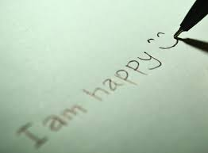

HappyDB is a corpus of 100,000 crowd-sourced happy moments via Amazon’s Mechanical Turk. You can read more about it on https://arxiv.org/abs/1801.07746.

In this project, we explore this data set and try to answer the question, “What makes people happy?”

## What do they focus on?

In this part, we want to find what makes people happy in general. Therefore the word cloud and frequent bigrams are shown below.

[interactive chart not shown]

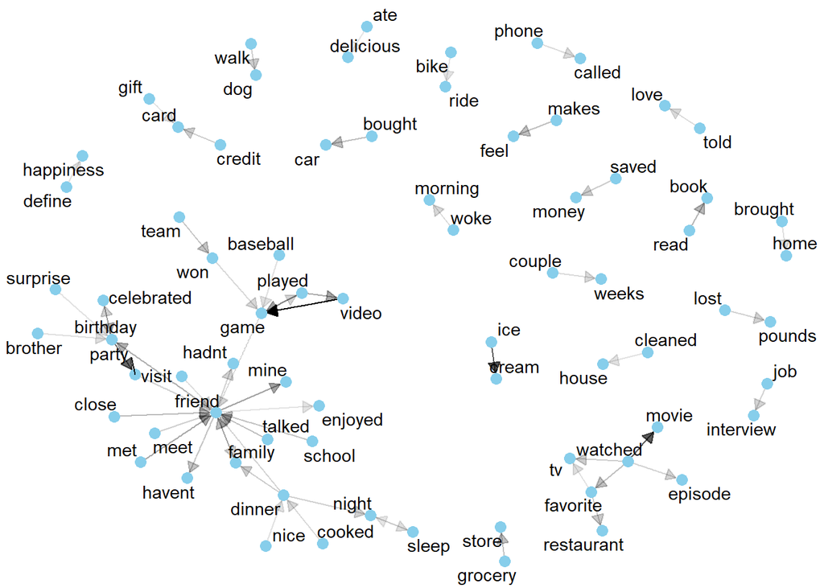

Hence the most frequently mentioned happy moments are those about relationships such as friends, families and so on. Then the second comes different enjoyments including games and food.

## How does gender affect the happy moments?

After getting a general idea about people’s happy moments, we want to figure out whether different groups of people have different sources of happiness. The first natural idea is to consider different genders.

For male, the word cloud and frequent bigrams are shown below.

[interactive chart not shown]

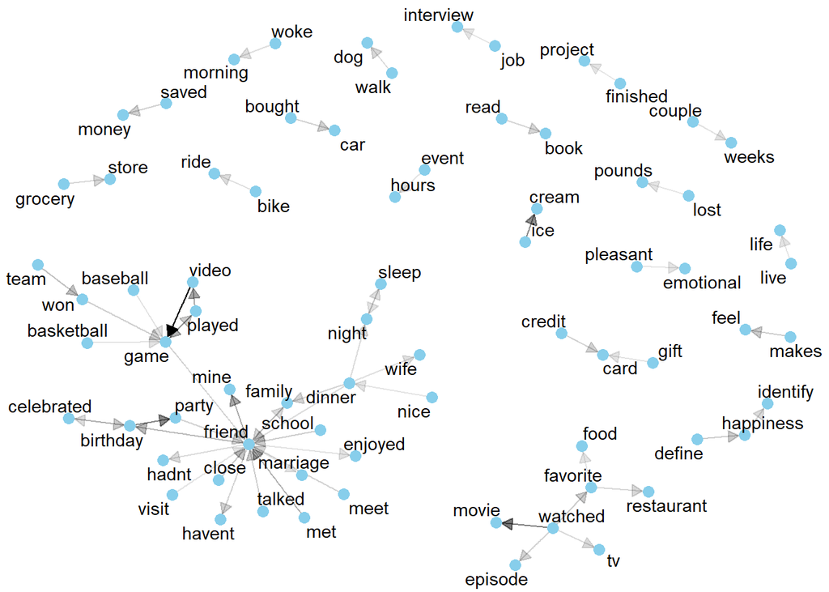

For female, the results are shown below.

[interactive chart not shown]

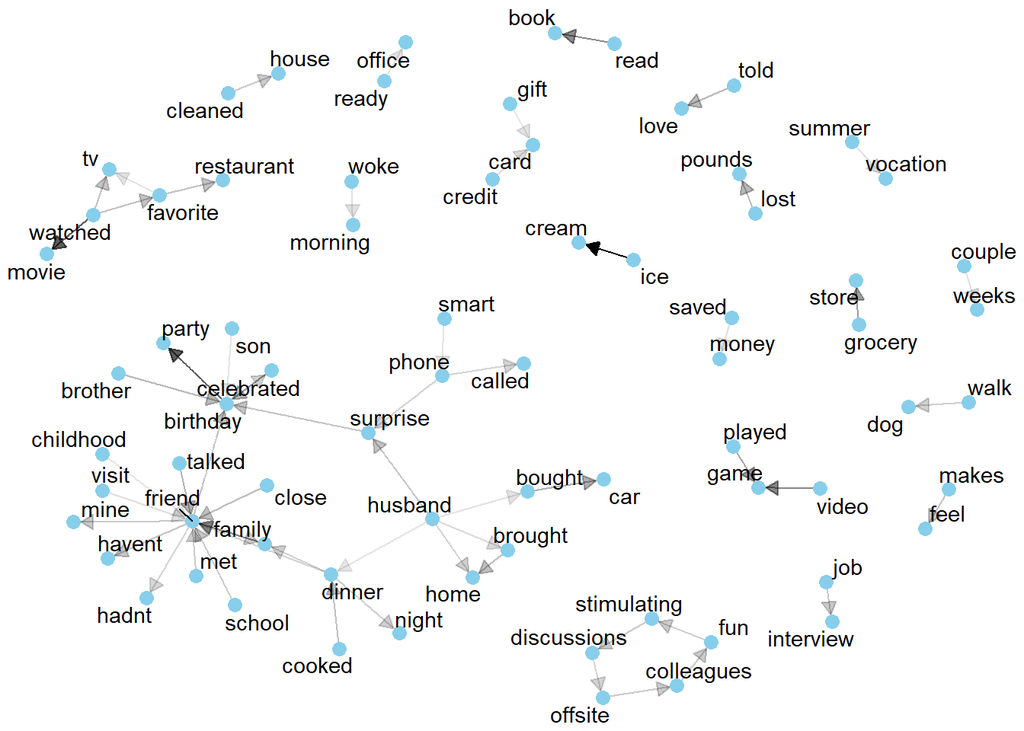

We also want to compare the most frequent words and predicted categories for different genders.

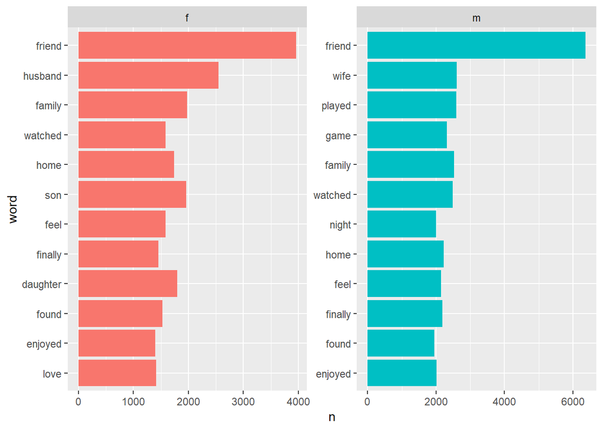

```
## [1] "male"
```

```
##
##      achievement        affection          bonding enjoy_the_moment
##       0.36634409       0.29069892       0.11249104       0.11612903
##         exercise          leisure           nature
##       0.01435484       0.08387097       0.01611111
```

```
## [1] "female"
```

```
##
##      achievement        affection          bonding enjoy_the_moment
##      0.296450346      0.409837760      0.099565981      0.102356102
##         exercise          leisure           nature
##      0.008938721      0.061951018      0.020900072
```

As a result, it’s reasonable to conclude that achievement, exercise and leisure make male happier, while affection is more important to female. In addition, the female cares more about their children, while men obtain more happiness from entertainments.

## What role does marital play?

Second, we want to compare whether single/married people have different happy moments.

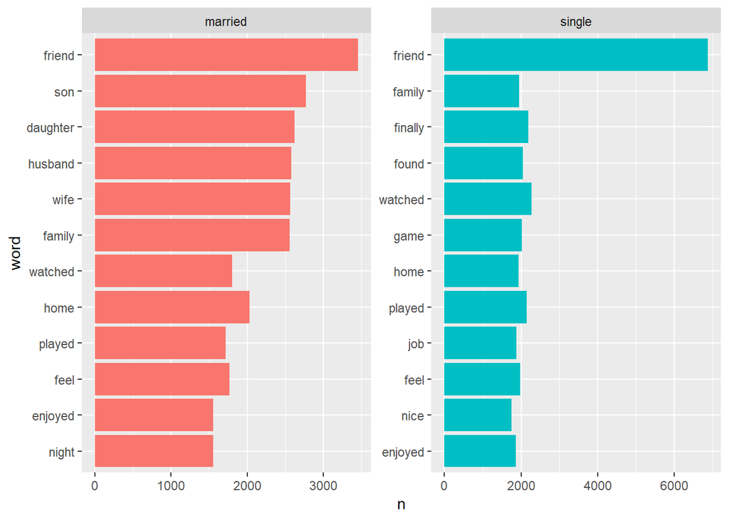

```
## [1] "single"
```

```
##
##      achievement        affection          bonding enjoy_the_moment
##       0.37134214       0.26710116       0.12756541       0.11918056
##         exercise          leisure           nature
##       0.01501429       0.08160750       0.01818895
```

```
## [1] "married"
```

```
##
##      achievement        affection          bonding enjoy_the_moment
##      0.293757172      0.434141459      0.080568373      0.099123514
##         exercise          leisure           nature
##      0.008374228      0.066114895      0.017920359
```

The result is as expected that singles gain more happiness from many aspects of personal life, while the married people tend to care more about their family, obtaining more happiness from affection.

## How about the parenthood?

Third, we want to discover how parenthood affects people’s happy moments.

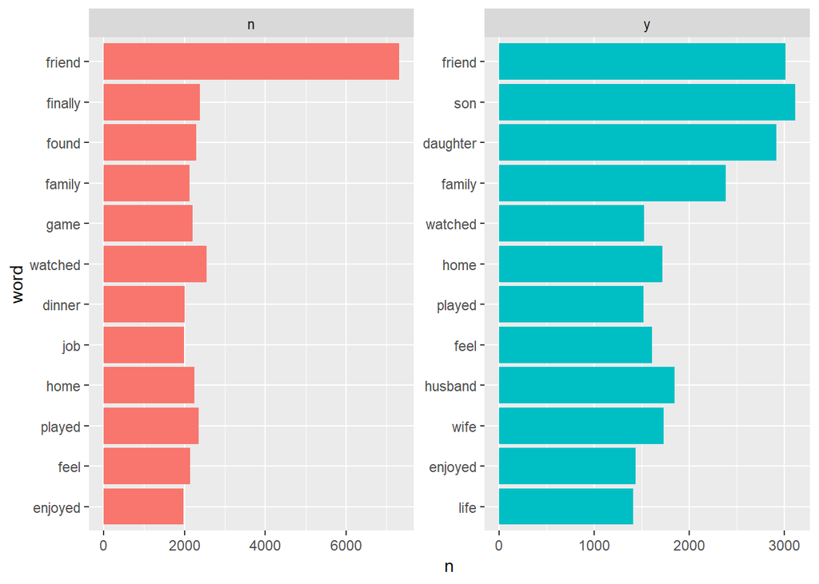

```
## [1] "y"
```

```
##
##      achievement        affection          bonding enjoy_the_moment
##      0.289924088      0.455166811      0.079666097      0.098069974
##         exercise          leisure           nature
##      0.007451189      0.053334827      0.016387014
```

```
## [1] "n"
```

```
##
##      achievement        affection          bonding enjoy_the_moment
##       0.36672958       0.26927851       0.12390961       0.11802615
##         exercise          leisure           nature
##       0.01498070       0.08797973       0.01909572
```

Similar to marital, people with parenthood tend to gain more happiness from family, having more happy moments about affection. On the other hand, people without parenthood mainly achieve happiness from all the other perspectives.

## Does reflection period makes a difference?

Forth, we want to know whether the reflection period affects the happy moments.

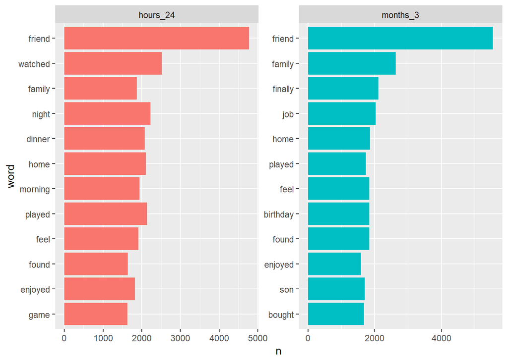

```
## [1] "24h"
```

```
##
##      achievement        affection          bonding enjoy_the_moment
##       0.30882102       0.32891145       0.10535745       0.13265654
##         exercise          leisure           nature
##       0.01548371       0.08765569       0.02111414
```

```
## [1] "3m"
```

```
##
##      achievement        affection          bonding enjoy_the_moment
##      0.366169677      0.349916002      0.109008820      0.088660227
##         exercise          leisure           nature
##      0.008840823      0.062326753      0.015077698
```

In the long term, people mainly keep happy about achievement and affection. While in the short term, people also gain happiness from enjoyment, exercise and leisure.

## What do young/elder people feel happy about?

Finally, we compare people younger than 30 with people older than 30.

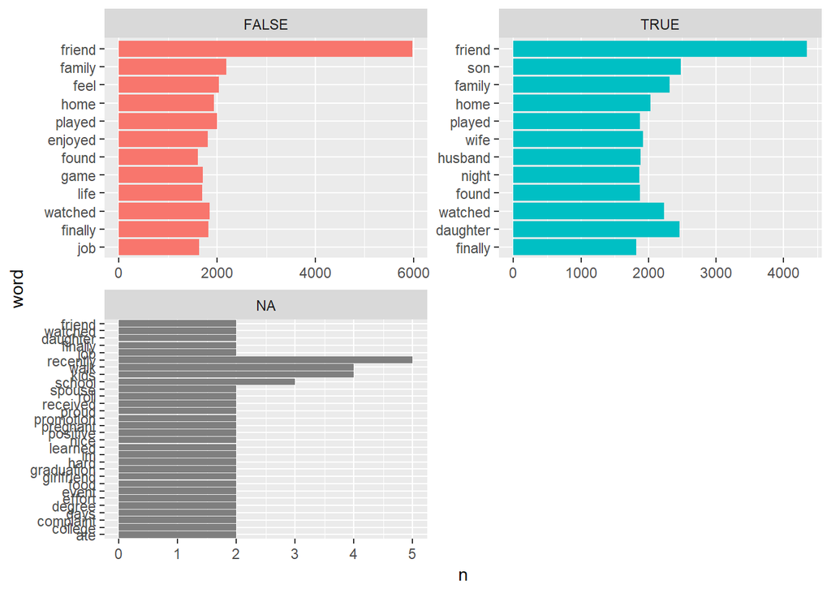

```
## [1] "below30"
```

```
##
##      achievement        affection          bonding enjoy_the_moment
##       0.34567220       0.30568409       0.12293586       0.11414866
##         exercise          leisure           nature
##       0.01407225       0.08394532       0.01354162
```

```
## [1] "above30"
```

```
##
##      achievement        affection          bonding enjoy_the_moment
##       0.32976500       0.37311290       0.09157324       0.10683896
##         exercise          leisure           nature
##       0.01021938       0.06591922       0.02257131
```

For people below 30 years old, they gain more happiness from achievement, bonding, enjoyment, exercise and leisure. While those above 30 years old tend to have more happy moments about their family and nature.

### Summary

By analyzing the happy moments for different groups of people, we could get the following results.

- The most frequently mentioned happy moments are those about relationships including friends, families. Then the second comes different ways of enjoyment.
- Achievement, exercise and leisure make male happier, while affection is more important to female. In addition, the female cares more about their children, while men obtain more happiness from entertainments.
- Singles gain more happiness from different aspects of personal life, while the married people tend to care more about their family, obtaining more happiness from affection.
- People with parenthood tend to gain more happiness from family, having more happy moments about affection. On the other hand, people without parenthood mainly achieve happiness from achievements and other enjoyments.
- In the long term, people mainly keep happy about achievement and affection. While in the short term, people also gain happiness from enjoyment, exercise and leisure.
- People below 30 years old gain more happiness from achievement, bonding, enjoyment, exercise and leisure. While those above 30 years old tend to have more happy moments about their families and nature.